# Recall and Recognition in Visual Working Memory

October 8, 2018

## Previously, in the last episode …

- We fitted the Interference Model to Single-probe Change-detection task with the help of Bayesian inference rule.
  - and we did good.

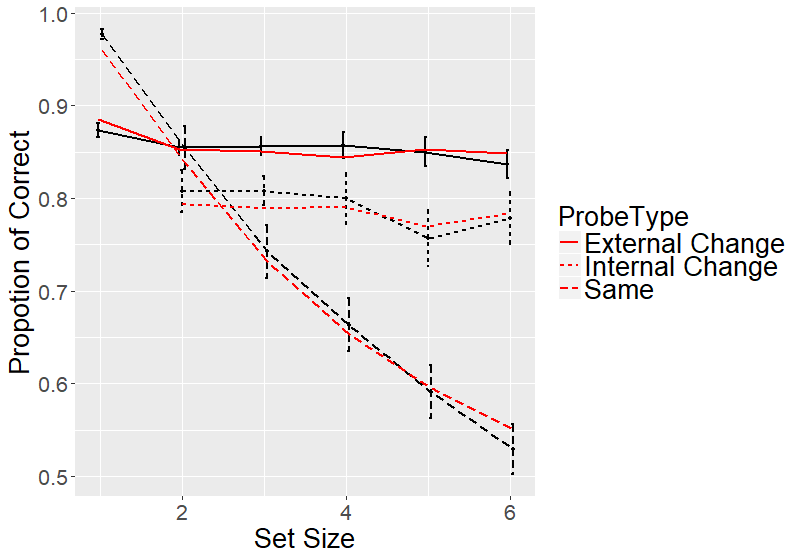

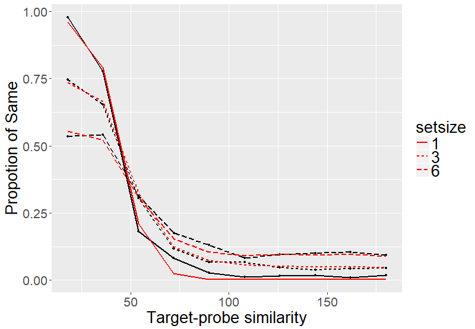

## However

- Since we have a model which can fit bot recall and recognition task.
  - Can we do it at the same time?
  - Why?
- Do recall and recognition share similar retrieval process?
  - It seems intuitive
  - But not many models can do it.
- Do recall and recognition process tap into the same memory representation?
  - Check if the mixture model estimated similar parameters for both recall and recognition

## Mixture model

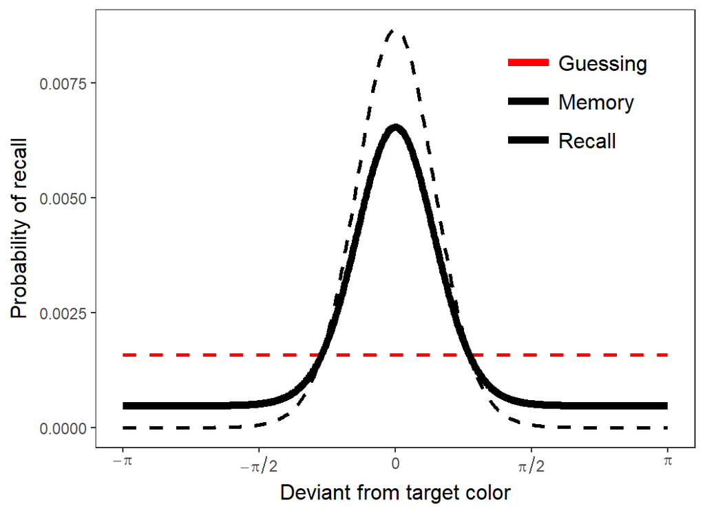

## Bayesian inference rule

- To adapt the recall model to recognition, we used the Bayesian inference rule.

\[ d(x, \varphi) = \log[\frac{p("change"|x, \varphi)}{p("same"|x, \varphi)}] \\ = \log[\frac{p(x, \varphi|"change")\cdot p("change")}{p(x, \varphi|"same")\cdot p("same")}]\]

- You recall the color from the probed location \(x\) and, given the probe color \(\varphi\), evaluate the probability of *change* or *same*.
- When \(d(x, \varphi) > 0\), the probe is more likely coming from *change* condition,
- and vice versa.

## Bayesian inference rule

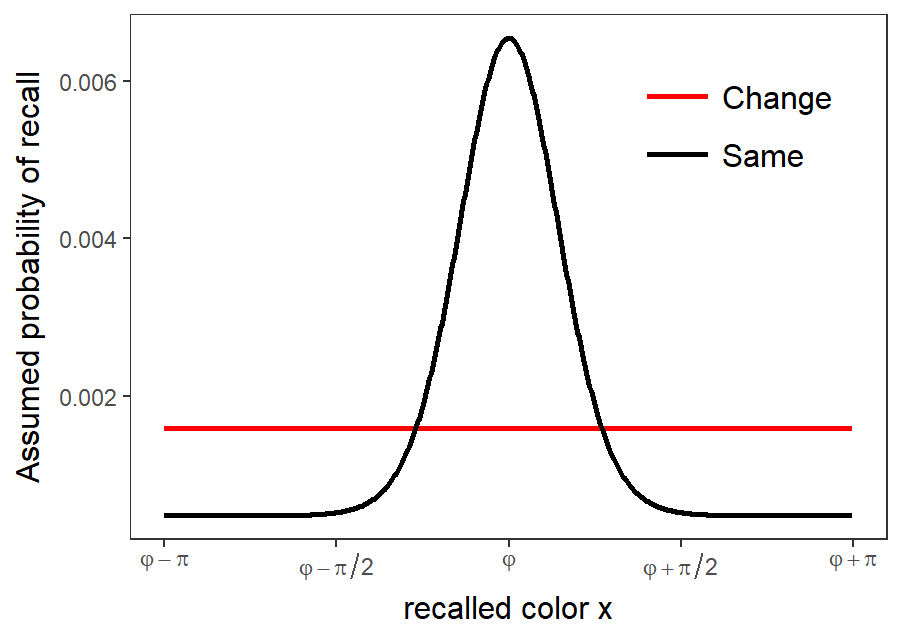

- If the recalled color is similar enough to the probe color, respond *same*
- Otherwise, respond *change*
- How similar is determined by the assumed recall distribution.

## Experiment

- 20 participants
- Four sessions, 512 trials per session
  - 1 session of full recall
  - 1 session of full recognition
  - 2 session of recall and recognition
- Setsize: 1, 2, 4, 6.

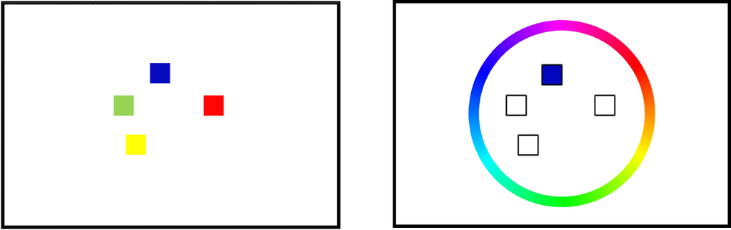

## Experiment

- 20 participants
- Four sessions, 512 trials per session
  - 1 session of full recall
  - 1 session of full recognition
  - 2 session of recall and recognition
- Setsize: 1, 2, 4, 6.

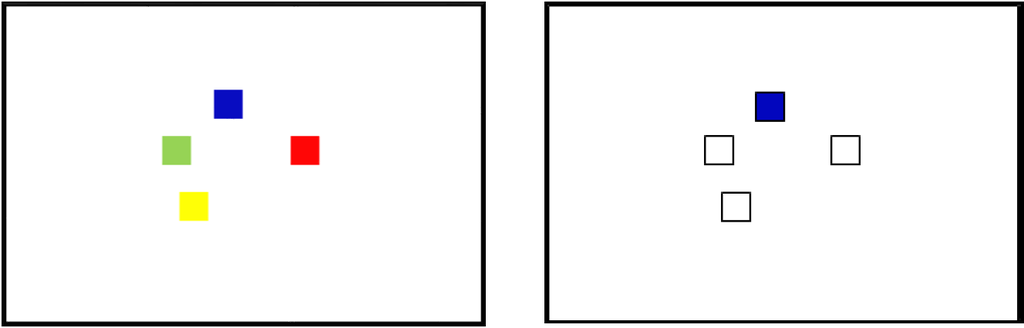

## Experiment

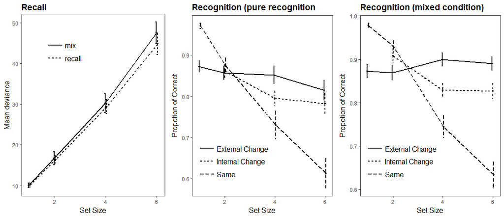

## Mixture model results

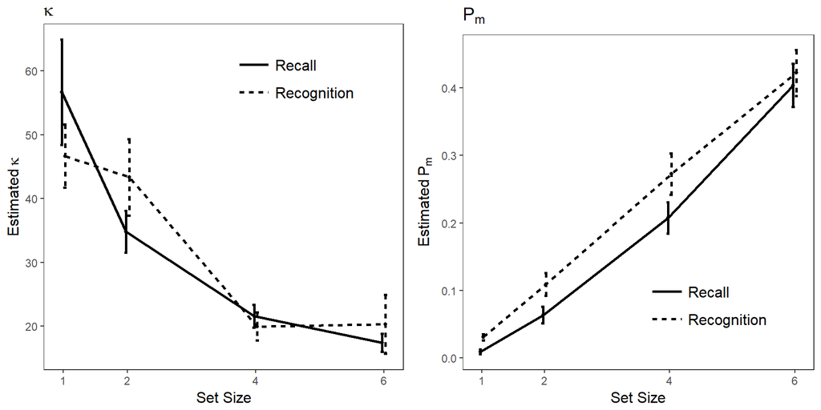

- Well, that's a bit of a problem.

## Knowledge limited model

- Nosofsky & Donkin (2016):
  - One additional parameter \(C\), how similar tht probe and the recalled color needs to be to be accepted.

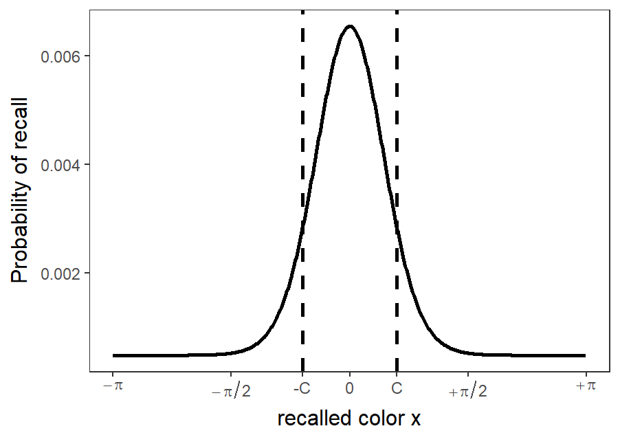

## Bayesian inference with bias

- Instead of responding *change* when \(d(x, \varphi) > 0\), the *change* criterior is changed to \(d(x, \varphi) > b\)

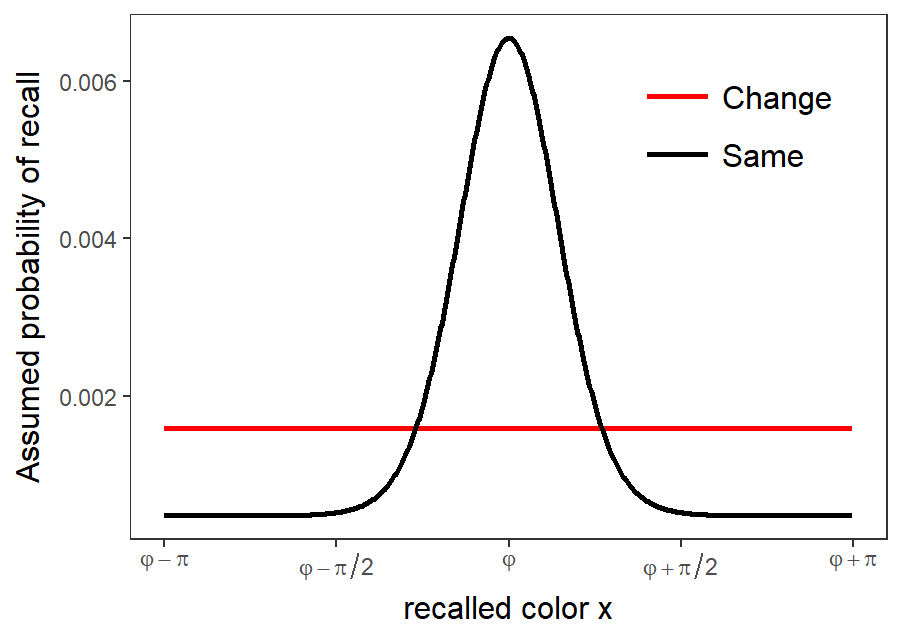

## Fitting results, again

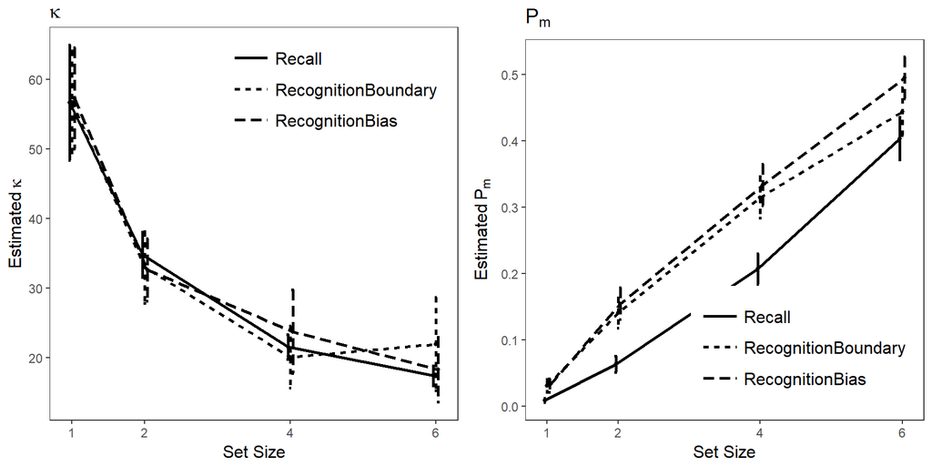

## Fitting results, again

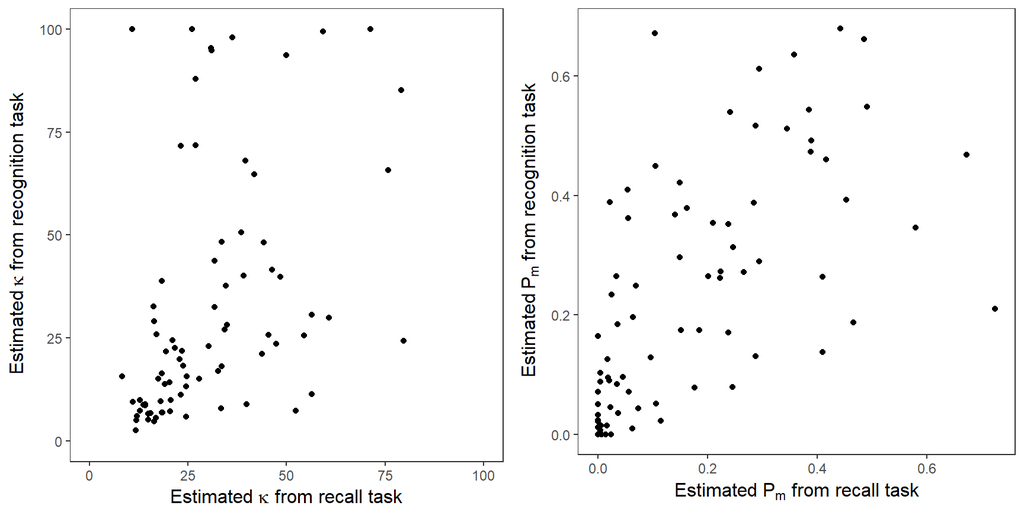

## And that's it.

## Fitting results, again

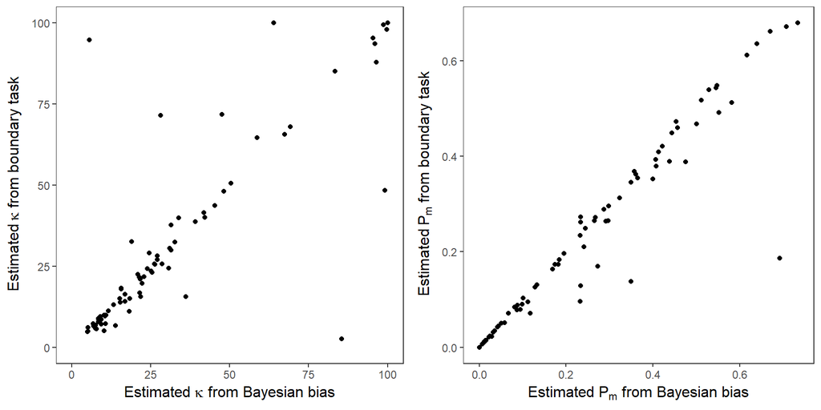